# STAT 240 Discussion 9

## Problems

The questions in this discussion assignment use the chimpanzee data set. In answering these questions, you may assume the following in models for the data:

1. all trials are independent
2. trials made with a partner have the same chance of being pro-social, even if the identities of the actors or partners differ.

### Problem 1

#### A

Using the chimpanzee data, combine all of the trials made without a partner. Count the number of pro-social and selfish choices made.

```r
chimpanzee <- read_csv("../../data/chimpanzee.csv")
FINALQ1 <- chimpanzee %>% filter(partner == "none")
sum(FINALQ1$prosocial)
```

```
## [1] 83
```

```r
sum(FINALQ1$selfish)
```

```
## [1] 97
```

83 Pro-Social, 97 Selfish choices made.

#### B

Write a model for the number of pro-social choices.

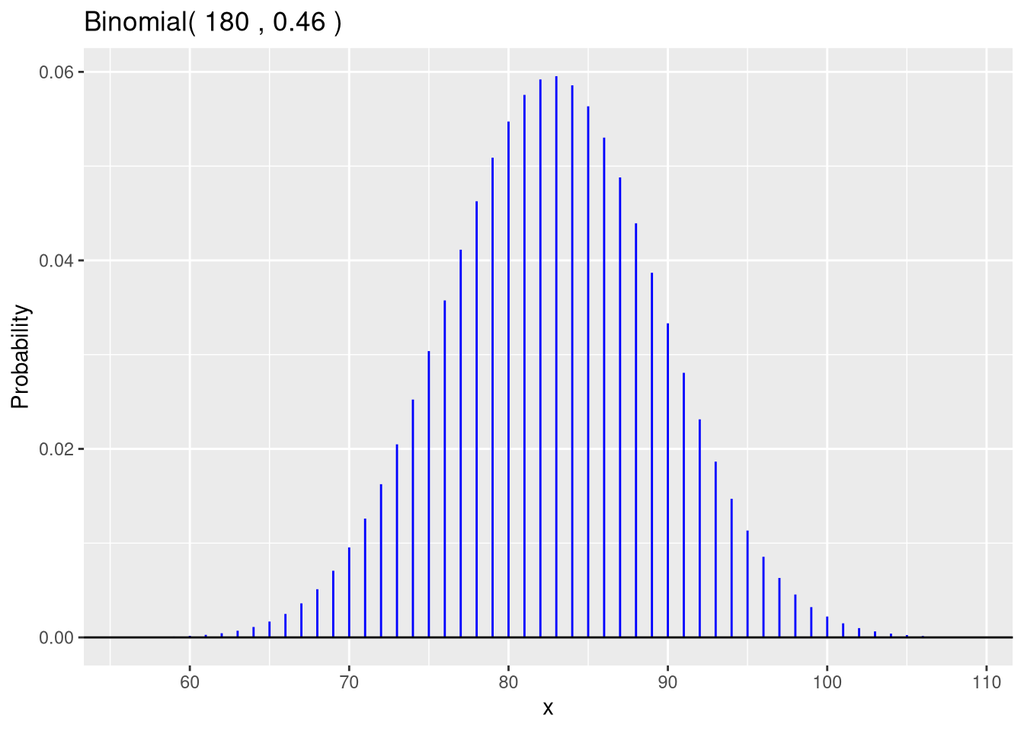

```r
gbinom(180, 0.46, scale=TRUE)
```

#### C

Use the Agresti-Coull method to construct a 95% confidence interval for the probability that a chimpanzee makes the pro-social choice in experimental conditions when there is no partner present.

#### D

Interpret this confidence interval in the context of the experimental setting.

### Problem 2

Using the same data as in the previous problem, do the following.

#### A

State hypotheses for a two-sided hypothesis test that the probability that a chimpanzee makes the pro-social choice over the long run is equal to 0.5 versus the alternative that this probability is not 0.5.

$H_0: p = 0.5 \\ H_a: p \neq 0.5$

#### B

Pick a test statistic, state the sampling distribution of this statistic if the null hypothesis is true, and compute a p-value for the test.

#### C

Interpret these results in the context of the experiment following the examples from lecture notes.

### 3

Use functions from the file `ggprob.R` to visualize the calculation of the p-value by graphing an appropriate probability distribution and using differential coloring to indicate what in the plot corresponds to the p-value. Include a title and meaningful axis labels.